# Authorship Attribution and Educational Data Mining

## Authorship Attribution

The package libraries and dataset used in this homework problem are loaded, and the data is then cleaned by removing the unnecessary attribute, “filename”. Two data frames are then created from the initial dataset; one data frame contains the rows of data with the author attribute value “Hamilton” or “Madison”, and the other data frame contains the rows of data with the author attribute value “dispt”. The factor() method is then used to assure that only the required levels of the author factor are included in the data.

```r
library(rpart)
library(caret)
library(rpart.plot)
library(rattle)
essayData <- read.csv("Disputed_Essay_data.csv", TRUE, ",")
essayData <- essayData[,!(names(essayData) %in% c("filename"))]
dataHamMad <- essayData[-c(1:11,63:70),]
dataDispt <- essayData[-c(12:85),]
dataHamMad$author <- factor(dataHamMad$author)
dataDispt$author <- factor(dataDispt$author)
str(dataHamMad)
```

```
## 'data.frame':    66 obs. of  71 variables:
##  $ author: Factor w/ 2 levels "Hamilton","Madison": 1 1 1 1 1 1 1 1 1 1 ...
##  $ a     : num  0.213 0.369 0.305 0.391 0.327 0.26 0.261 0.449 0.392 0.194 ...
##  $ all   : num  0.083 0.07 0.047 0.045 0.096 0.065 0.108 0.022 0.05 0.081 ...
##  $ also  : num  0 0.006 0.007 0.015 0 0 0 0 0.004 0 ...
##  $ an    : num  0.083 0.076 0.068 0.03 0.086 0.087 0.072 0.074 0.075 0.089 ...
##  $ and   : num  0.343 0.411 0.386 0.27 0.356 0.274 0.467 0.353 0.329 0.413 ...
##  $ any   : num  0.056 0.023 0.047 0.045 0.014 0.079 0.018 0.044 0.029 0.065 ...
##  $ are   : num  0.111 0.053 0.102 0.06 0.086 0.022 0.045 0.059 0.075 0.138 ...
##  $ as    : num  0.093 0.117 0.108 0.09 0.072 0.13 0.027 0.133 0.104 0.186 ...
##  $ at    : num  0.065 0.065 0.088 0.015 0.115 0.079 0.063 0.029 0.05 0.024 ...
##  $ be    : num  0.315 0.258 0.271 0.376 0.211 0.397 0.216 0.295 0.221 0.356 ...
##  $ been  : num  0.028 0.018 0.054 0.03 0.067 0.051 0.027 0.081 0.067 0.049 ...
##  $ but   : num  0 0.023 0.041 0.03 0.034 0.036 0.009 0.015 0.05 0.024 ...
##  $ by    : num  0.13 0.106 0.095 0.075 0.154 0.094 0.081 0.162 0.125 0.089 ...
```

[output cut: 57 more lines]

```r
str(dataDispt)
```

```
## 'data.frame':    11 obs. of  71 variables:
##  $ author: Factor w/ 1 level "dispt": 1 1 1 1 1 1 1 1 1 1 ...
##  $ a     : num  0.28 0.177 0.339 0.27 0.303 0.245 0.349 0.414 0.248 0.442 ...
##  $ all   : num  0.052 0.063 0.09 0.024 0.054 0.059 0.036 0.083 0.04 0.062 ...
##  $ also  : num  0.009 0.013 0.008 0.016 0.027 0.007 0.007 0.009 0.007 0.006 ...
##  $ an    : num  0.096 0.038 0.03 0.024 0.034 0.067 0.029 0.018 0.04 0.075 ...
##  $ and   : num  0.358 0.393 0.301 0.262 0.404 0.282 0.335 0.478 0.356 0.423 ...
##  $ any   : num  0.026 0.063 0.008 0.056 0.04 0.052 0.058 0.046 0.034 0.037 ...
##  $ are   : num  0.131 0.051 0.068 0.064 0.128 0.111 0.087 0.11 0.154 0.093 ...
##  $ as    : num  0.122 0.139 0.203 0.111 0.148 0.252 0.073 0.074 0.161 0.1 ...
##  $ at    : num  0.017 0.114 0.023 0.056 0.013 0.015 0.116 0.037 0.047 0.031 ...
##  $ be    : num  0.411 0.393 0.474 0.365 0.344 0.297 0.378 0.331 0.289 0.379 ...
##  $ been  : num  0.026 0.165 0.015 0.127 0.047 0.03 0.044 0.046 0.027 0.025 ...
##  $ but   : num  0.009 0 0.038 0.032 0.061 0.037 0.007 0.055 0.027 0.037 ...
##  $ by    : num  0.14 0.139 0.173 0.167 0.209 0.186 0.102 0.092 0.168 0.174 ...
```

[output cut: 57 more lines]

The dataset containing the essays written by either Hamilton or Madison is split into training and testing datasets. Before splitting the data, set.seed() is first used with an arbitrary value so that the same results are achieved when this code is replicated (as long as the same seed value is used). The method ‘createDataPartition()’ is used to split the data into training and testing datasets, with its first parameter being the target attribute (“author”) of the dataset, its second parameter representing the percentage of the data to put into the training dataset (80% training, 20% testing), and the third parameter indicating that a list should not be returned from the method. The result of ‘createDataPartition()’ is then used to put the data into separate training and testing data frames.

```r
set.seed(123)
split <- createDataPartition(y = dataHamMad$author, p= 0.8, list = FALSE)
trainSet <- dataHamMad[split,]
testSet <- dataHamMad[-split,]
dim(trainSet);
```

```
## [1] 53 71
```

```r
dim(testSet);
```

```
## [1] 13 71
```

The training dataset is trained based on the target attribute “author”, with the tuning parameters “metric” and “method” specified. The printed model indicates that the maximum accuracy achieved in this model was 91.28%, and the complexity parameter chosen for this model was 0.4583.

```r
set.seed(234)
dt_model <- train(author ~ ., data = trainSet, metric = "Accuracy", method = "rpart")
print(dt_model)
```

```
## CART
##
## 53 samples
## 70 predictors
##  2 classes: 'Hamilton', 'Madison'
##
## No pre-processing
## Resampling: Bootstrapped (25 reps)
## Summary of sample sizes: 53, 53, 53, 53, 53, 53, ...
## Resampling results across tuning parameters:
##
##   cp         Accuracy   Kappa
##   0.0000000  0.9127817  0.7691170
##   0.4583333  0.9127817  0.7691170
##   0.9166667  0.8467170  0.4263794
##
## Accuracy was used to select the optimal model using the largest value.
## The final value used for the model was cp = 0.4583333.
```

The “author” attribute was then predicted for the testing dataset based on the model built from the training dataset. The probabilities of each prediction being correct for each entry in the dataset are first displayed, followed by the raw predicted values for the “author” attribute. The confusion matrix is then displayed for this model, indicating that the model was able to accurately predict the authors for the entire testing dataset.

```r
dt_predict <- predict(dt_model, newdata = testSet, type="prob")
dt_predict
```

```
##      Hamilton   Madison
## 12 1.00000000 0.0000000
## 13 1.00000000 0.0000000
## 17 1.00000000 0.0000000
## 27 1.00000000 0.0000000
## 34 1.00000000 0.0000000
## 45 1.00000000 0.0000000
## 47 1.00000000 0.0000000
## 49 1.00000000 0.0000000
## 50 1.00000000 0.0000000
## 59 1.00000000 0.0000000
## 73 0.07692308 0.9230769
## 82 0.07692308 0.9230769
## 85 0.07692308 0.9230769
```

```r
dt_predict2 <- predict(dt_model, newdata = testSet, type="raw")
dt_predict2
```

```
##  [1] Hamilton Hamilton Hamilton Hamilton Hamilton Hamilton Hamilton
##  [8] Hamilton Hamilton Hamilton Madison  Madison  Madison
## Levels: Hamilton Madison
```

```r
confusionMatrix(dt_predict2,testSet$author)
```

```
## Confusion Matrix and Statistics
##
##           Reference
## Prediction Hamilton Madison
##   Hamilton       10       0
##   Madison         0       3
##
##                Accuracy : 1
##                  95% CI : (0.7529, 1)
##     No Information Rate : 0.7692
##     P-Value [Acc > NIR] : 0.03302
##
##                   Kappa : 1
##
##  Mcnemar's Test P-Value : NA
##
##             Sensitivity : 1.0000
##             Specificity : 1.0000
##          Pos Pred Value : 1.0000
##          Neg Pred Value : 1.0000
##              Prevalence : 0.7692
##          Detection Rate : 0.7692
##    Detection Prevalence : 0.7692
##       Balanced Accuracy : 1.0000
##
##        'Positive' Class : Hamilton
##
```

```r
control <- trainControl(method = "repeatedcv", number = 8, repeats = 3)
set.seed(345)
dt_model_tune <- train(author ~.,data = trainSet, method = "rpart",trControl=control, tuneLength=8)
print(dt_model_tune)
```

```
## CART
##
## 53 samples
## 70 predictors
##  2 classes: 'Hamilton', 'Madison'
##
## No pre-processing
## Resampling: Cross-Validated (8 fold, repeated 3 times)
## Summary of sample sizes: 46, 47, 47, 46, 46, 47, ...
## Resampling results across tuning parameters:
##
##   cp         Accuracy   Kappa
##   0.0000000  0.9623016  0.87184874
##   0.1309524  0.9623016  0.87184874
##   0.2619048  0.9623016  0.87184874
##   0.3928571  0.9623016  0.87184874
##   0.5238095  0.9623016  0.87184874
##   0.6547619  0.9623016  0.87184874
##   0.7857143  0.9623016  0.87184874
##   0.9166667  0.7772817  0.07282913
##
## Accuracy was used to select the optimal model using the largest value.
## The final value used for the model was cp = 0.7857143.
```

```r
dt_predict3 <- predict(dt_model_tune, newdata = testSet, type="prob")
dt_predict3
```

```
##      Hamilton   Madison
## 12 1.00000000 0.0000000
## 13 1.00000000 0.0000000
## 17 1.00000000 0.0000000
## 27 1.00000000 0.0000000
## 34 1.00000000 0.0000000
## 45 1.00000000 0.0000000
## 47 1.00000000 0.0000000
## 49 1.00000000 0.0000000
## 50 1.00000000 0.0000000
## 59 1.00000000 0.0000000
## 73 0.07692308 0.9230769
## 82 0.07692308 0.9230769
## 85 0.07692308 0.9230769
```

Both models predicted the authors of the testing dataset with 100% accuracy, with the second model yielding slightly higher overall accuracy when trained. The second model was therefore chosen as the best performance model, and was used to predict the authors of the dataset containing the essays with disputed authors. It was predicted that the author of all 11 disputed papers was Madison, with a correctness of 92.3% for each prediction.

```r
dt_predictDispt <- predict(dt_model_tune, newdata = dataDispt, type="prob")
dt_predictDispt
```

```
##      Hamilton   Madison
## 1  0.07692308 0.9230769
## 2  0.07692308 0.9230769
## 3  0.07692308 0.9230769
## 4  0.07692308 0.9230769
## 5  0.07692308 0.9230769
## 6  0.07692308 0.9230769
## 7  0.07692308 0.9230769
## 8  0.07692308 0.9230769
## 9  0.07692308 0.9230769
## 10 0.07692308 0.9230769
## 11 0.07692308 0.9230769
```

```r
predict(dt_model_tune, newdata = dataDispt, type="raw")
```

```
##  [1] Madison Madison Madison Madison Madison Madison Madison Madison
##  [9] Madison Madison Madison
## Levels: Hamilton Madison
```

Two visualizations of the decision tree created from the best performance model are shown below. The prediction of authorship was based on the frequency in which the word “upon” was used in each author’s essays.

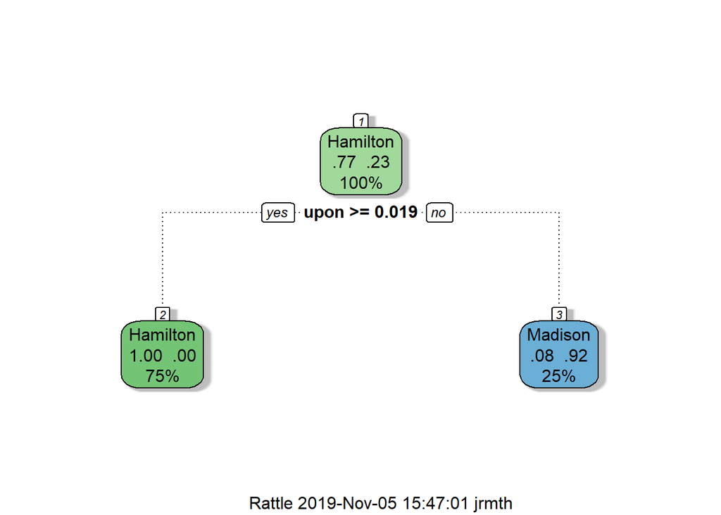

```r
fancyRpartPlot(dt_model_tune$finalModel)
```

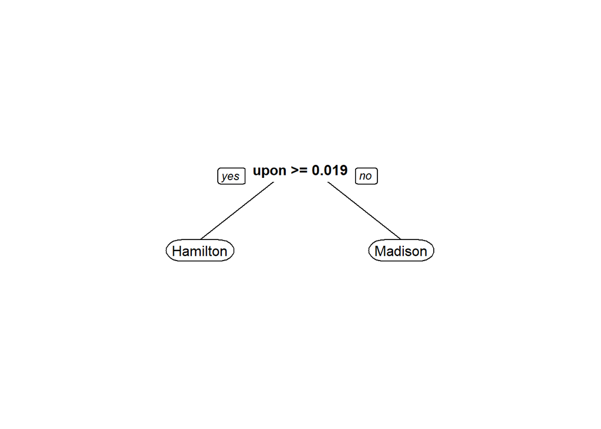

```r
prp(dt_model_tune$finalModel)
```

## Educational Data Mining

The package libraries and dataset used in this homework problem are first loaded.

```r
library(recipes)
library(tidyverse)
library(rsample)
library(keras)
library(tidyquant)
student_data <- read.csv("Students_ Academic Performance.csv", TRUE, ",")
str(student_data)
```

```
## 'data.frame':    480 obs. of  17 variables:
##  $ gender                  : Factor w/ 2 levels "F","M": 2 2 2 2 2 1 2 2 1 1 ...
##  $ NationalITy             : Factor w/ 14 levels "Egypt","Iran",..: 5 5 5 5 5 5 5 5 5 5 ...
##  $ PlaceofBirth            : Factor w/ 14 levels "Egypt","Iran",..: 5 5 5 5 5 5 5 5 5 5 ...
##  $ StageID                 : Factor w/ 3 levels "HighSchool","lowerlevel",..: 2 2 2 2 2 2 3 3 3 3 ...
##  $ GradeID                 : Factor w/ 10 levels "G-02","G-04",..: 2 2 2 2 2 2 5 5 5 5 ...
##  $ SectionID               : Factor w/ 3 levels "A","B","C": 1 1 1 1 1 1 1 1 1 2 ...
##  $ Topic                   : Factor w/ 12 levels "Arabic","Biology",..: 8 8 8 8 8 8 9 9 9 8 ...
##  $ Semester                : Factor w/ 2 levels "F","S": 1 1 1 1 1 1 1 1 1 1 ...
##  $ Relation                : Factor w/ 2 levels "Father","Mum": 1 1 1 1 1 1 1 1 1 1 ...
##  $ raisedhands             : int  15 20 10 30 40 42 35 50 12 70 ...
##  $ VisITedResources        : int  16 20 7 25 50 30 12 10 21 80 ...
##  $ AnnouncementsView       : int  2 3 0 5 12 13 0 15 16 25 ...
##  $ Discussion              : int  20 25 30 35 50 70 17 22 50 70 ...
##  $ ParentAnsweringSurvey   : Factor w/ 2 levels "No","Yes": 2 2 1 1 1 2 1 2 2 2 ...
##  $ ParentschoolSatisfaction: Factor w/ 2 levels "Bad","Good": 2 2 1 1 1 1 1 2 2 2 ...
##  $ StudentAbsenceDays      : Factor w/ 2 levels "Above-7","Under-7": 2 2 1 1 1 1 1 2 2 2 ...
##  $ Class                   : Factor w/ 3 levels "H","L","M": 3 3 2 2 3 3 2 3 3 3 ...
```

The data preprocessing begins by pruning the data of any potential NA values and moving the target ‘Class’ column to be the first column in the dataset. The seed is set so that the same partition can be replicated when using that seed value in the future. The data is then split into training and testing datasets, with 80% of the data put into the training dataset and 20% into the testing dataset.

```r
student_data_tbl <- student_data %>%
  drop_na() %>%
  select(Class, everything())
str(student_data_tbl)
```

```
## 'data.frame':    480 obs. of  17 variables:
##  $ Class                   : Factor w/ 3 levels "H","L","M": 3 3 2 2 3 3 2 3 3 3 ...
##  $ gender                  : Factor w/ 2 levels "F","M": 2 2 2 2 2 1 2 2 1 1 ...
##  $ NationalITy             : Factor w/ 14 levels "Egypt","Iran",..: 5 5 5 5 5 5 5 5 5 5 ...
##  $ PlaceofBirth            : Factor w/ 14 levels "Egypt","Iran",..: 5 5 5 5 5 5 5 5 5 5 ...
##  $ StageID                 : Factor w/ 3 levels "HighSchool","lowerlevel",..: 2 2 2 2 2 2 3 3 3 3 ...
##  $ GradeID                 : Factor w/ 10 levels "G-02","G-04",..: 2 2 2 2 2 2 5 5 5 5 ...
##  $ SectionID               : Factor w/ 3 levels "A","B","C": 1 1 1 1 1 1 1 1 1 2 ...
##  $ Topic                   : Factor w/ 12 levels "Arabic","Biology",..: 8 8 8 8 8 8 9 9 9 8 ...
##  $ Semester                : Factor w/ 2 levels "F","S": 1 1 1 1 1 1 1 1 1 1 ...
##  $ Relation                : Factor w/ 2 levels "Father","Mum": 1 1 1 1 1 1 1 1 1 1 ...
##  $ raisedhands             : int  15 20 10 30 40 42 35 50 12 70 ...
##  $ VisITedResources        : int  16 20 7 25 50 30 12 10 21 80 ...
##  $ AnnouncementsView       : int  2 3 0 5 12 13 0 15 16 25 ...
##  $ Discussion              : int  20 25 30 35 50 70 17 22 50 70 ...
##  $ ParentAnsweringSurvey   : Factor w/ 2 levels "No","Yes": 2 2 1 1 1 2 1 2 2 2 ...
##  $ ParentschoolSatisfaction: Factor w/ 2 levels "Bad","Good": 2 2 1 1 1 1 1 2 2 2 ...
##  $ StudentAbsenceDays      : Factor w/ 2 levels "Above-7","Under-7": 2 2 1 1 1 1 1 2 2 2 ...
```

```r
set.seed(100)
train_test_split <- initial_split(student_data_tbl, prop = 0.8)
train_tbl <- training(train_test_split)
test_tbl <- testing(train_test_split)
dim(train_tbl)
```

```
## [1] 385  17
```

```r
dim(test_tbl)
```

```
## [1] 95 17
```

```r
rec_obj <- recipe(Class ~ ., data = train_tbl) %>%
  step_discretize(raisedhands, options = list(cuts = 5)) %>%
  step_discretize(VisITedResources, options = list(cuts = 5)) %>%
  step_discretize(AnnouncementsView, options = list(cuts = 5)) %>%
  step_discretize(Discussion, options = list(cuts = 5)) %>%
  step_dummy(all_nominal(), -all_outcomes()) %>%
  step_center(all_predictors(), -all_outcomes()) %>%
  step_scale(all_predictors(), -all_outcomes()) %>%
  prep(data = train_tbl)
rec_obj
```

```
## Data Recipe
##
## Inputs:
##
##       role #variables
##    outcome          1
##  predictor         16
##
## Training data contained 385 data points and no missing data.
##
## Operations:
##
## Dummy variables from raisedhands [trained]
## Dummy variables from VisITedResources [trained]
## Dummy variables from AnnouncementsView [trained]
## Dummy variables from Discussion [trained]
## Dummy variables from gender, NationalITy, PlaceofBirth, StageID, ... [trained]
## Centering for gender_M, ... [trained]
## Scaling for gender_M, ... [trained]
```

The training and testing datasets are then split further into training and testing sets that do not contain the target ‘Class’ attribute (x sets), and sets that only contain the target attribute (y sets). The x sets are created via the ‘bake()’ method, which takes as input the recipe object just created, as well as the training dataset. The y sets are created via nested if-else statements, which convert the ‘Class’ attribute values of ‘H’, ‘M’ and ‘L’ into the numerical values 2, 1, and 0, respectively. The newly created y training set is then converted into categorical data via the method ‘to_categorical()’.

```r
x_train_tbl <- bake(rec_obj, new_data = train_tbl) %>% select(-Class)
x_test_tbl <- bake(rec_obj, new_data = test_tbl) %>% select(-Class)
glimpse(x_train_tbl)
```

```
## Observations: 385
## Variables: 76
## $ gender_M                      <dbl> 0.750715, 0.750715, 0.750715, 0....
## $ NationalITy_Iran              <dbl> -0.1256583, -0.1256583, -0.12565...
## $ NationalITy_Iraq              <dbl> -0.2079611, -0.2079611, -0.20796...
## $ NationalITy_Jordan            <dbl> -0.7297108, -0.7297108, -0.72971...
## $ NationalITy_KW                <dbl> 1.2707645, 1.2707645, 1.2707645,...
## $ NationalITy_lebanon           <dbl> -0.1791313, -0.1791313, -0.17913...
## $ NationalITy_Lybia             <dbl> -0.1256583, -0.1256583, -0.12565...
## $ NationalITy_Morocco           <dbl> -0.1023299, -0.1023299, -0.10232...
## $ NationalITy_Palestine         <dbl> -0.2575059, -0.2575059, -0.25750...
## $ NationalITy_SaudiArabia       <dbl> -0.1359059, -0.1359059, -0.13590...
## $ NationalITy_Syria             <dbl> -0.1145588, -0.1145588, -0.11455...
## $ NationalITy_Tunis             <dbl> -0.1545121, -0.1545121, -0.15451...
## $ NationalITy_USA               <dbl> -0.1145588, -0.1145588, -0.11455...
```

[output cut: 63 more lines]

```r
y_train_vec <- ifelse(pull(train_tbl, Class) == "H" | pull(train_tbl, Class) == "M",
                      ifelse(pull(train_tbl, Class) == "H", 2, 1), 0)
y_test_vec  <- ifelse(pull(test_tbl, Class) == "H" | pull(test_tbl, Class) == "M",
                      ifelse(pull(test_tbl, Class) == "H", 2, 1), 0)
glimpse(y_train_vec)
```

```
##  num [1:385] 1 1 0 1 1 1 1 1 2 0 ...
```

```r
glimpse(y_test_vec)
```

```
##  num [1:95] 0 0 1 1 2 1 1 0 2 0 ...
```

```r
y_train_vec<-to_categorical(y_train_vec,num_classes = NULL)
```

A class of artificial neural networks, a multi-layer perceptron, was built using the ‘keras’ package. The input to this model is simply the (x set) training data. This model consists of two hidden layers, created via the ‘layer.dense()’ method. Each hidden layer was implemented via a uniform kernel initializer and the relu activation function. The hidden layers consist of 20 and 10 nodes, respectively. The first layer has an input shape equal to the total number of columns in the input dataset. The dropout layers all have a rate of 0.20, which controls layer overfitting. The number of nodes in the output layer is equal to the number of categories in the target attribute (3 nodes), and it is implemented via a uniform kernel initializer and the softmax activation function. The ‘compile()’ method was used to compile the data, using the optimization algorithm, ‘adam’, a loss equal to categorical_crossentropy, and it measured the accuracy for the datasets.

```r
model_keras <- keras_model_sequential()
model_keras %>%
  layer_dense(units = 20,
    kernel_initializer = "uniform",
    activation = "relu",
    input_shape = ncol(x_train_tbl)) %>%
  layer_dropout(rate = 0.20) %>%
  layer_dense(units = 10,
    kernel_initializer = "uniform",
    activation = "relu") %>%
  layer_dropout(rate = 0.20) %>%
  layer_dense(units = 3,
    kernel_initializer = "uniform",
    activation = "softmax") %>%
  compile(optimizer = "adam",
    loss = "categorical_crossentropy",
    metrics = c("accuracy")
  )
model_keras
```

```
## Model
## ___________________________________________________________________________
## Layer (type)                     Output Shape                  Param #
## ===========================================================================
## dense (Dense)                    (None, 20)                    1540
## ___________________________________________________________________________
## dropout (Dropout)                (None, 20)                    0
## ___________________________________________________________________________
## dense_1 (Dense)                  (None, 10)                    210
## ___________________________________________________________________________
## dropout_1 (Dropout)              (None, 10)                    0
## ___________________________________________________________________________
## dense_2 (Dense)                  (None, 3)                     33
## ===========================================================================
## Total params: 1,783
## Trainable params: 1,783
## Non-trainable params: 0
## ___________________________________________________________________________
```

The input dataset is trained on our neural network via the method ‘fit()’. This method takes as input the newly created model, as well as the x and y training datasets. The sample size to be trained at one time was set via the batch_size parameter (batch size set to 55), and the amount of training cycles (epochs) was set to 130. The validation_split parameter was set to 0.20 to control overfitting. The ‘plot()’ method is used to visualize the trained model, via observing the training and validation loss and accuracy. As the loss and accuracy level off in the plot, the training completes. The method ‘predict_classes()’, which accepts as input our trained model and our test data, is used to make predictions on the test dataset. A tibble is then created to display the side-by-side comparison of the predicted data and the actual data values. A confusion matrix is then displayed, showing more specifically the number of correct and incorrect predictions made for each value of the target ‘Class’ attribute. The confusion matrix also displays the accuracy achieved through this artificial neural network model. This model yielded an overall accuracy of roughly 70-73%. Although this performance can be improved, a significant number of the target ‘Class’ attributes were successfully predicted based on the training model.

```r
fit_keras <- fit(
    object           = model_keras,
    x                = as.matrix(x_train_tbl),
    y                = y_train_vec,
    batch_size       = 55,
    epochs           = 130,
    validation_split = 0.20
    )
fit_keras
```

```
## Trained on 308 samples (batch_size=55, epochs=130)
## Final epoch (plot to see history):
##     loss: 0.2444
##      acc: 0.9123
## val_loss: 0.6732
##  val_acc: 0.5844
```

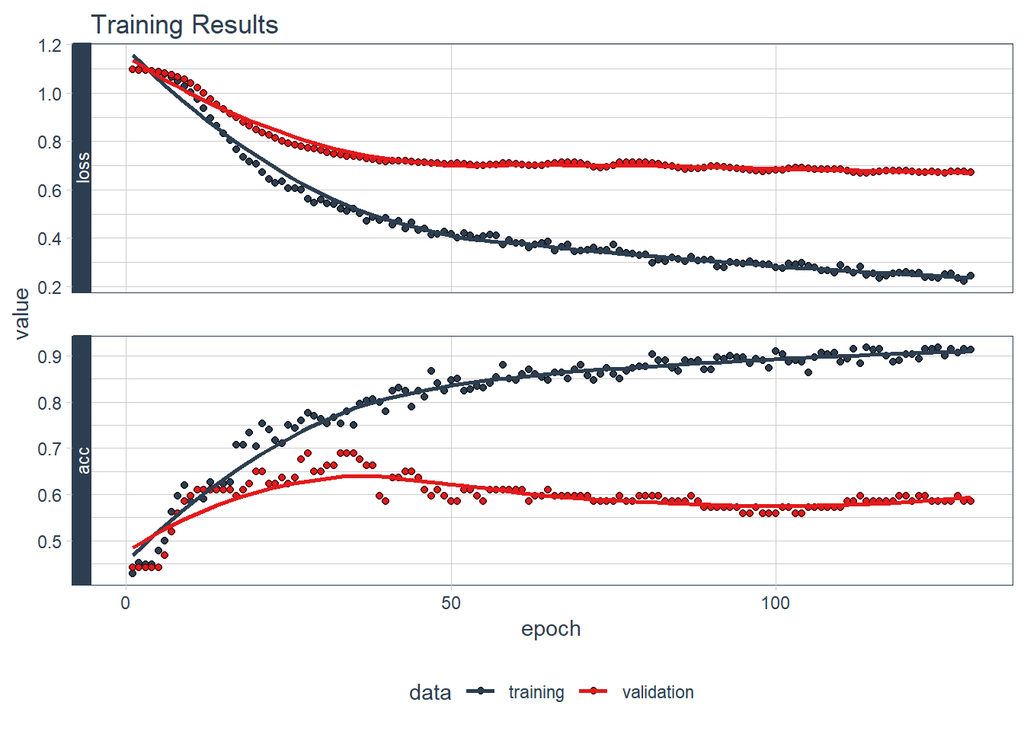

```r
plot(fit_keras) +
    theme_tq() +
    scale_color_tq() +
    scale_fill_tq() +
    labs(title = "Training Results")
```

```r
yhat_keras_class_vec <- predict_classes(object = model_keras, x = as.matrix(x_test_tbl)) %>%
    as.vector()
truth      = as.factor(y_test_vec) %>% fct_recode(H="2",M="1",L="0")
estimate   = as.factor(yhat_keras_class_vec) %>% fct_recode(H="2",M="1",L="0")
estimates_keras_tbl <- tibble(truth,estimate)
estimates_keras_tbl
```

```
## # A tibble: 95 x 2
##    truth estimate
##    <fct> <fct>
##  1 L     L
##  2 L     L
##  3 M     M
##  4 M     M
##  5 H     M
##  6 M     M
##  7 M     M
##  8 L     L
##  9 H     M
## 10 L     L
## # ... with 85 more rows
```

```r
confusionMatrix(truth, estimate)
```

```
## Confusion Matrix and Statistics
##
##           Reference
## Prediction  L  M  H
##          L 15  8  0
##          M  1 27 11
##          H  0  8 25
##
## Overall Statistics
##
##                Accuracy : 0.7053
##                  95% CI : (0.6029, 0.7944)
##     No Information Rate : 0.4526
##     P-Value [Acc > NIR] : 5.627e-07
##
##                   Kappa : 0.5407
##
##  Mcnemar's Test P-Value : NA
##
## Statistics by Class:
##
##                      Class: L Class: M Class: H
## Sensitivity            0.9375   0.6279   0.6944
## Specificity            0.8987   0.7692   0.8644
## Pos Pred Value         0.6522   0.6923   0.7576
## Neg Pred Value         0.9861   0.7143   0.8226
## Prevalence             0.1684   0.4526   0.3789
## Detection Rate         0.1579   0.2842   0.2632
## Detection Prevalence   0.2421   0.4105   0.3474
## Balanced Accuracy      0.9181   0.6986   0.7794
```